# MID-TERM PROJECT: HEDONIC HOME PRICE PREDICTION IN SAN FRANCISCO

Allison Carr, Jeong Hoon Kim

October 29th, 2019

### 1. Introduction

Applications like Zillow have opened the door for non-relators the participate in the real-estate industry with more information about housing values in their neighborhood or a neighborhood where they wish to live. These success of these applications hinges on their ability to accurately predict home prices using three main categories of features:

```
1) Internal Characteristics: How many bathrooms does the home have? What is the home's square footage?
2) Amenities: Is the house near a train station or school?
3) Spatial Relationships: What price are homes in the neighborhood valued at? What price are homes on the block valued at?
```

#### 1-1. Baseline Data

The map below shows the distribution of home sales by price from a dataset that we recieved for our analysis. Based on the map, we can recognize that housings having high prices are clustred in the north and central area in San Francisco. The baseline data also includes internal characteristics of the homes such as the property area and number of bedrooms and bathrooms.

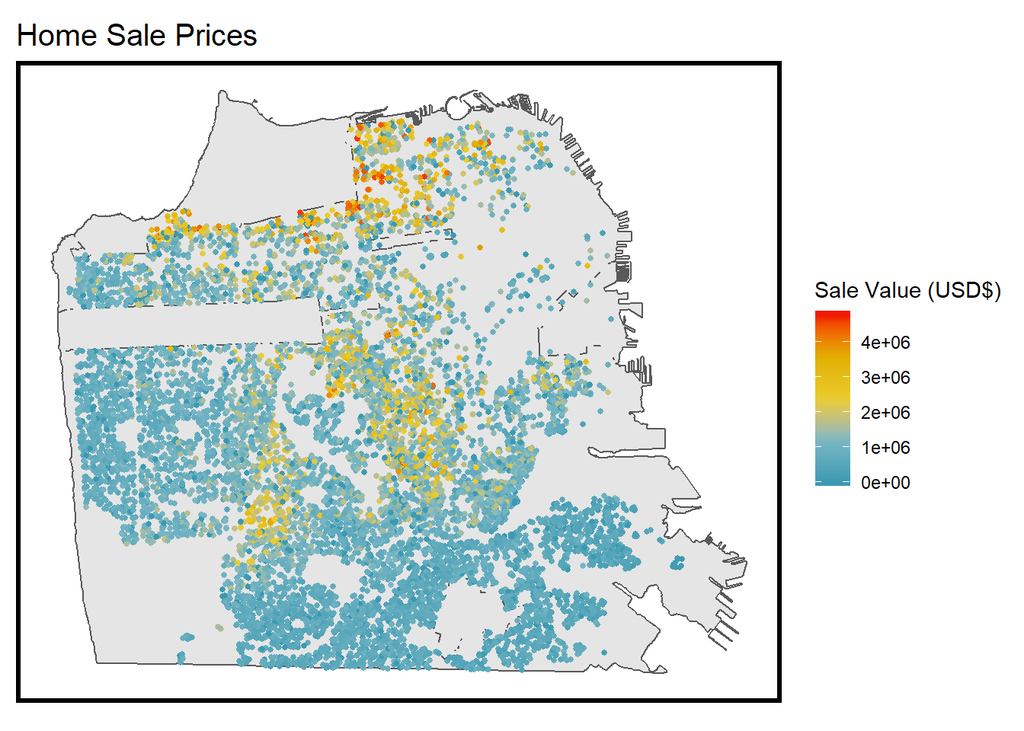

```r
dat_sf <-
  dat %>%
  st_as_sf(coords = c("X", "Y"), crs = 2227, agr = "constant")

ggplot() +
  geom_sf(data=st_union(baseMap)) +
  geom_sf(data = dat_sf, aes(colour = SalePrice), show.legend = "point", size = 1) +
  labs(title="Home Sale Prices") +
  scale_colour_gradientn(colours=pal, name = "Sale Value (USD$)") +
  mapTheme()
```

#### 1-2. Existing Housing Price by Neighborhood

To get an idea of the spatial relationships that exist between home prices, we evaluated the sales prices across San Francisco’s major neighborhoods. The plot and map below show the distribution of the total mean value of the median housing prices by neighborhoods. The mean home value in most neighborhoods is around one million dollar. Only one neighborhood has homes priced over 3 million dollars.

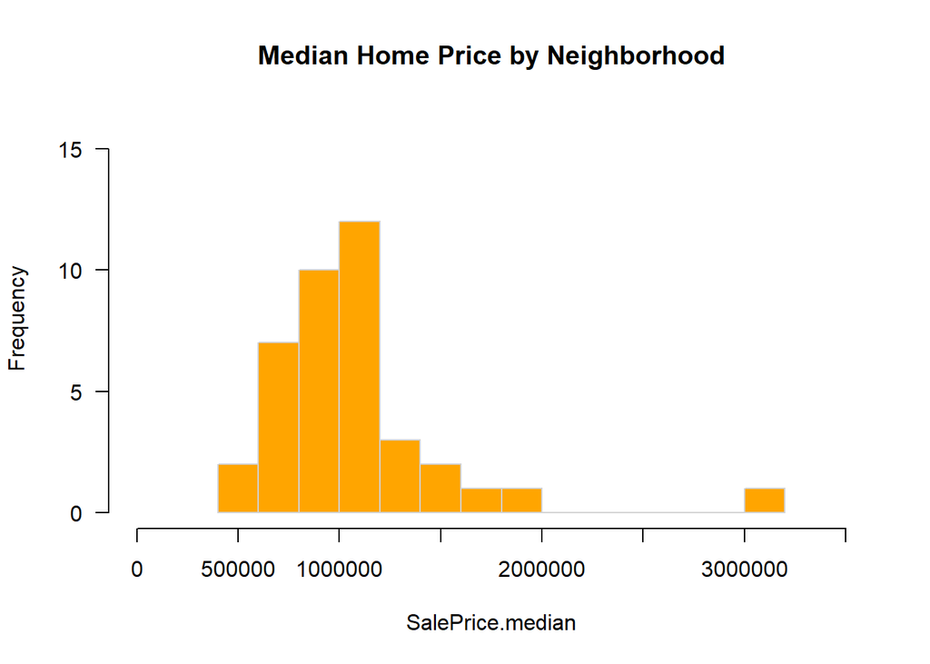

```r
dat.nhood <- dat %>%
  group_by(nhood) %>%
  summarise(SalePrice.median = mean(SalePrice)
  )

sf_join <- merge(x = baseMap, y = dat.nhood, by = "nhood", all.x = TRUE)

hist(sf_join$SalePrice.median,
     main="Median Home Price by Neighborhood",
     xlab="SalePrice.median",
     border="light grey",
     col="orange",
     xlim = c(000000,3500000),
     ylim = c(0,16),
     las=1,
     length(diag(4)),
     breaks=15)
```

**Map of Median Home Price by Neighborhood**

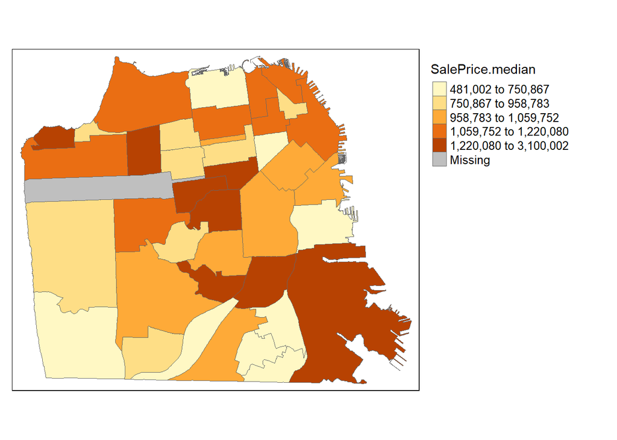

```r
tm_shape(sf_join) +
  tm_fill(style="quantile", col = "SalePrice.median") +
  tm_borders(lwd=0.5) +
  tm_legend(outside = TRUE, text.size = .8)
```

### 2. Data Preparation and Preliminary Tests

Input data for our model, also called independent variables, were collected from the following open source data providers: San Francisco Open Data, California Open Data, and the US Census Bureau. The following data lists are the independent variables tested for our models. There are three different type of variables in our dataset: continuous variable, categorical variable and binary variable.

We generated a number of independent variables using the baseline data and the data that we collected. Although the table below lists over 30 features that we considered, only 13 features were eventually deemed significant enough to be included in the final model. The following steps show how we narrowed our model down to those 13 features.

```r
vars.list <- read.csv("C:/Users/user/Desktop/Spatial/Midterm_R/midterm-vars-list.csv")

vars.list %>%
  kable() %>%
  kable_styling(bootstrap_options = c("striped", "hover", "condensed"))
```

[output not shown]

#### 2-1. Summary Statistics

Based on the statistic chart, we excluded some outlier datasets, such as a property having over 400 stories, for making the better regression model.

```r
dat <- dat[!(dat$Stories==829),]
dat <- dat[!(dat$Stories==742),]
dat <- dat[!(dat$Stories==432),]

stargazer(dat, type="text", title = "Summary Statistics")
```

```
##
## Summary Statistics
## ==============================================================================================================
## Statistic               N        Mean       St. Dev.        Min        Pctl(25)      Pctl(75)         Max
## --------------------------------------------------------------------------------------------------------------
## FID                   10,130   5,066.146    2,925.584        0          2,532.2       7,599.8       10,132
## SaleDate              10,130  135,189.300  11,060.030     120,103       121,221       141,202       151,231
## X                     10,130 5,998,984.000  8,958.325  5,980,569.000 5,992,445.000 6,005,324.000 6,020,464.000
## Y                     10,130 2,100,274.000  8,449.661  2,086,052.000 2,094,043.000 2,105,272.000 2,121,818.000
## long                  10,130    37.747        0.023       37.708        37.730        37.761        37.806
## lat                   10,130   -122.446       0.031      -122.511      -122.469      -122.425      -122.371
## SalePrice             10,130 1,065,591.000 736,219.000       0         642,602.5     1,330,002     4,750,003
## Cate_Zone             10,130     0.016        0.125          0             0             0             1
## PropArea              10,130   1,635.616     783.848         0           1,150         1,970        24,308
## BuiltYear             10,130   1,915.500     190.100         0           1,913         1,948         2,016
## Cate_Year             10,130     1.807        0.630          1             1             2             3
## Stories               10,130     1.338        0.682          0             1             2            10
## Beds                  10,130     1.692        1.710          0             0             3            20
## Baths                 10,130     1.793        1.022          0             1             2            25
## Count_ov1m            10,130    31.551       29.227          0             5            48            137
## Dist_School           10,130    907.826      477.383      24.228        542.957      1,202.401     3,320.439
## Count_Tree            10,130   1,016.690     553.915        10            599         1,427.8        3,065
## Count_311             10,130    201.142      177.294         0            96           236.8         1,419
## Dist_Transit          10,130    401.824      233.512      26.269        221.941       536.662      1,530.569
## Count_Theft16         10,130    99.272       143.161         3            36            97           2,542
## Count_Fire16          10,130    96.091       78.776         11            51            109          1,515
## Dist_Earth            10,130    944.560      867.271       0.000        268.875      1,398.621     4,648.201
## Val_Flood             10,130    44.969       12.189        0.000        36.566        52.273        84.819
## Dist_Tabaco           10,130    995.576      649.873      23.766        518.847      1,295.882     4,224.848
## Count_Food            10,130    19.637       25.114          0             4            25            286
## Dist_Road             10,130   3,176.157    2,230.820     41.881       1,294.718     4,638.533     9,208.768
## median_HH.income      10,116  102,494.900  31,376.830   16,473.000    80,352.000    128,517.000   205,865.000
## monthly_cost.under200 10,125    15.192       14.986        0.000         0.000        22.000        72.000
## monthly_cost.over4000 10,125    222.199      177.835       0.000        84.000        313.000       979.000
## average_HH.size       10,125     2.734        0.609        1.330         2.230         3.110         4.030
## total_mortgage        10,125   1,040.027     468.876       0.000        715.000      1,279.000     2,883.000
## per_vacant            10,125     0.056        0.034        0.000         0.031         0.075         0.203
## per_white             10,125     0.473        0.215        0.059         0.312         0.645         0.868
## per_black             10,125     0.050        0.078        0.000         0.012         0.066         0.624
## per_asian             10,125     0.353        0.188        0.044         0.166         0.524         0.752
## per_hispanic          10,125     0.068        0.074        0.000         0.018         0.087         0.303
## per_owner.occupied    10,125     0.563        0.188        0.000         0.428         0.699         0.905
## holdOut               10,130     0.069        0.254          0             0             0             1
## BufferDist            10,130     0.250        0.000        0.250         0.250         0.250         0.250
## Cat_Flood             10,130     2.552        1.333          0             1             4             5
## --------------------------------------------------------------------------------------------------------------
```

#### 2-2. Evaluating Correlation

**Correlation Matrix**

After inspecting the summary statistics for the independent variables, we assessed their correlation with the dependent variable, the sales price. The figure below shows the degress of positive or negative correlation between all variables. Variables with a correlation closer to 1 or -1 are more likely to useful in the model.

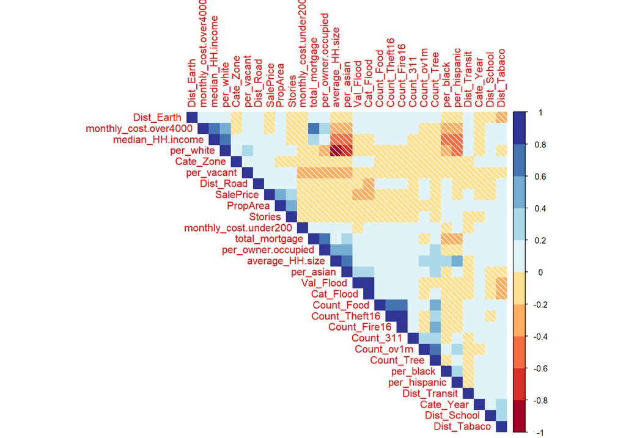

```r
datCor <-
  dat %>%
  dplyr::select(-ParcelID, -FID, -Address, -PropClassC, -SaleDate, -LandUse, -X, -Y, -long, -lat, -nhood, -holdOut, -BufferDist, -Census_Tracts, -Zoning, -BuiltYear, -Beds, -Baths)

datCor.pairs <- cor(datCor, use="pairwise.complete.obs")
corrplot(datCor.pairs, method = "shade", type="upper", order="hclust",
         col=brewer.pal(n=10, name="RdYlBu"))
```

**Correlation Scatterplots**

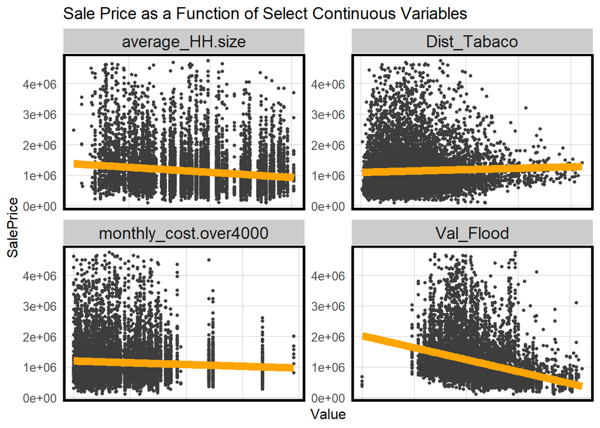

```r
as.data.frame(dat) %>%
  dplyr::select(SalePrice, Dist_Tabaco, Val_Flood, monthly_cost.over4000, average_HH.size) %>%
  filter(SalePrice >= 1) %>%
  gather(Variable, Value, -SalePrice) %>%
   ggplot(aes(Value, SalePrice)) +
     geom_point(colour = "#3d3d3d", size=1) +
     geom_smooth(method = "lm", se=F, colour = "orange", size=3) +
     facet_wrap(~Variable, ncol = 2, scales = "free") +
     labs(title = "Sale Price as a Function of Select Continuous Variables") +
     theme(axis.text.x = element_blank()) +
     plotTheme()
```

**Mapping Independent Variables**

The independent variables can also be mapped to assist in the evaluation. Variables that have a positive or negative spatial relationship with housing prices are more likely to be useful for modeling.

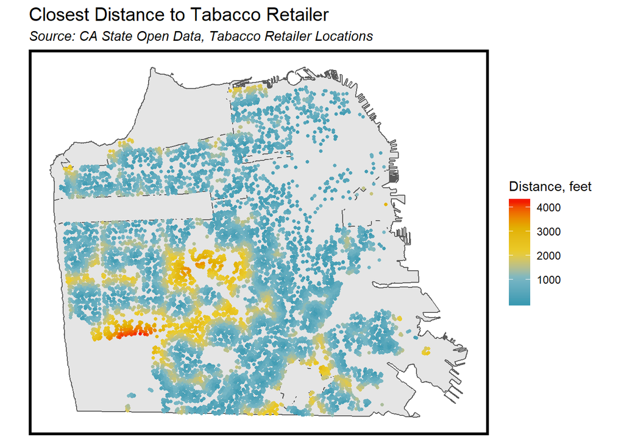

```r
par(mfrow=c(1,3))

ggplot() +
  geom_sf(data=st_union(baseMap)) +
  geom_sf(data = dat_sf, aes(color = Dist_Tabaco), show.legend = "point", size = 1) +
  labs(title="Closest Distance to Tabacco Retailer", subtitle = "Source: CA State Open Data, Tabacco Retailer Locations") +
  scale_colour_gradientn(colours=pal, name = "Distance, feet") +
  mapTheme()
```

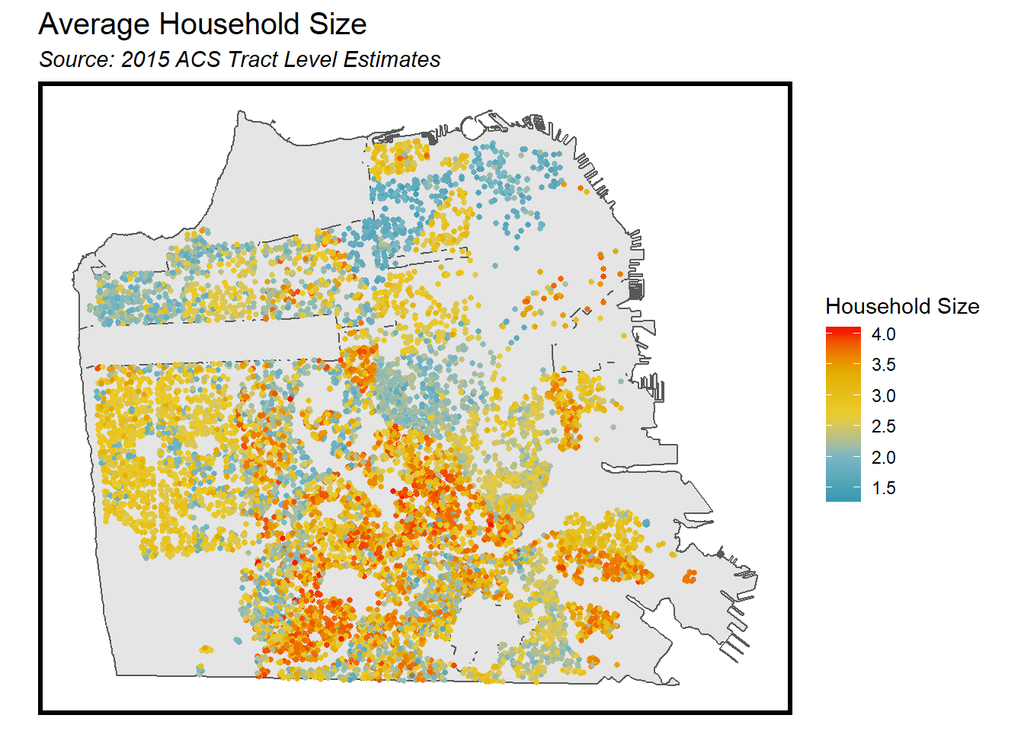

```r
ggplot() +
  geom_sf(data=st_union(baseMap)) +
  geom_sf(data = dat_sf, aes(color = average_HH.size), show.legend = "point", size = 1) +
  labs(title="Average Household Size", subtitle = "Source: 2015 ACS Tract Level Estimates") +
  scale_colour_gradientn(colours=pal, name = "Household Size") +
  mapTheme()
```

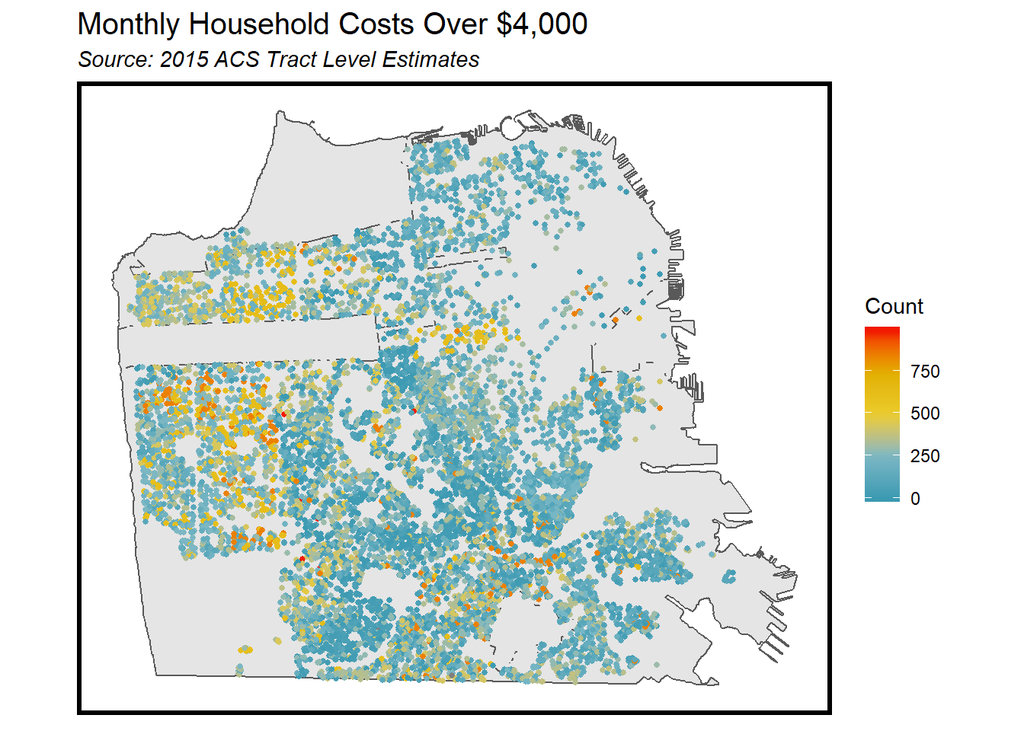

```r
ggplot() +
  geom_sf(data=st_union(baseMap)) +
  geom_sf(data = dat_sf, aes(colour = monthly_cost.over4000), show.legend = "point", size = 1) +
  labs(title="Monthly Household Costs Over $4,000", subtitle = "Source: 2015 ACS Tract Level Estimates") +
  scale_colour_gradientn(colours=pal, name = "Count") +
  mapTheme()
```

### 3. Modeling Method

We built our model based on the *hedonic* modeling method, which breaks the cost of a good down into the costs of its constituent parts. We have used an ordinary least squares linear regression to model the relationships between home prices and those constituent parts, or independent variables. As noted in the introduction, for housing sales those constituent parts are:

```
1) Internal Characteristics: How many bathrooms does the home have? What is the home's square footage?
2) Amenities: Is the house near a train station or school?
3) Spatial Relationships: What price are homes in the neighborhood valued at? What price are homes on the block valued at?
```

In addition to building a model that accurately predicts home prices in San Francisco, we also aimed to build a model that could be used to predict prices in different geographies. This quality is know as *generalizability.* Several of our tests in this Section as well as Sections 4 & 5 deal with the question of generalizability.

#### 3-1. Prepare the training and testing datasets

To begin, the datsets are devided into a test sets and training set. 75% of the observations are assigned to the training sets and the reamining are assigned to the test sets. We take this approach to ensure that our model is able to predict well for data that has *not* been used to train it (the remaining 25%). This will be addresses more below in *Cross Validation.*

```r
dat_sf <-
  dat %>%
  st_as_sf(coords = c("X", "Y"), crs = 2227, agr = "constant")

coords <- st_coordinates(dat_sf)
neighborList <- knn2nb(knearneigh(coords, 5))
spatialWeights <- nb2listw(neighborList, style="W")
dat_sf$lagPrice <- lag.listw(spatialWeights, dat_sf$SalePrice)

dat.noHold <- dat_sf %>%
  filter(holdOut == 0) %>%
    dplyr::select(SalePrice, PropArea, Cate_Zone, Cate_Year, Stories, Beds, Baths, Count_ov1m, Dist_School, Count_Tree, Count_311, Dist_Transit, Count_Theft16, Count_Fire16, Dist_Earth, Val_Flood, Dist_Tabaco, Dist_Road, median_HH.income, monthly_cost.under200, monthly_cost.over4000, average_HH.size, total_mortgage, per_vacant, per_white, per_black, per_asian, per_hispanic, per_owner.occupied, lagPrice, nhood, geometry)

dat.Hold <- dat_sf %>%
  filter(holdOut == 1) %>%
    dplyr::select(SalePrice, PropArea, Cate_Zone, Cate_Year, Stories, Beds, Baths, Count_ov1m, Dist_School, Count_Tree, Count_311, Dist_Transit, Count_Theft16, Count_Fire16, Dist_Earth, Val_Flood, Dist_Tabaco, Dist_Road, median_HH.income, monthly_cost.under200, monthly_cost.over4000, average_HH.size, total_mortgage, per_vacant, per_white, per_black, per_asian, per_hispanic, per_owner.occupied, lagPrice, nhood, geometry)

smp_siz = floor(0.75*nrow(dat.noHold))
set.seed(123)
train_ind = sample(seq_len(nrow(dat.noHold)),size = smp_siz)
dat.train =dat.noHold[train_ind,]
dat.test =dat.noHold[-train_ind,]
dat.test <- na.omit(dat.test)
```

#### 3-2 Regressions for Housing Price

**Regression Model 1**

```r
reg1.train <- lm(SalePrice ~ PropArea + Cate_Zone + Cate_Year + Stories + Beds + Baths + Count_ov1m + Dist_School + Count_Tree + Count_311 + Dist_Transit + Count_Theft16 + Count_Fire16 + Dist_Earth + Val_Flood + Dist_Tabaco + Dist_Road + median_HH.income + monthly_cost.under200 + monthly_cost.over4000 + average_HH.size + total_mortgage + per_vacant + per_white + per_black + per_asian + per_hispanic + per_owner.occupied + lagPrice,
          data = dat.train)
tab_model(reg1.train)
```

|  | Sale Price |  |  |
| --- | --- | --- | --- |
| Predictors | Estimates | CI | p |
| (Intercept) | 490222.51 | -9075.12 – 989520.14 | 0.054 |
| Prop Area | 221.30 | 202.76 – 239.83 | **<0.001** |
| Cate Zone | 153539.37 | 62878.29 – 244200.44 | **0.001** |
| Cate Year | -73560.99 | -92452.17 – -54669.82 | **<0.001** |
| Stories | 120238.20 | 101526.97 – 138949.44 | **<0.001** |
| Beds | -12288.26 | -20296.64 – -4279.88 | **0.003** |
| Baths | 30632.13 | 14695.16 – 46569.11 | **<0.001** |
| Count ov 1 m | -89.31 | -663.57 – 484.95 | 0.760 |
| Dist School | -46.04 | -70.50 – -21.59 | **<0.001** |
| Count Tree | 15.40 | -17.02 – 47.82 | 0.352 |
| Count 311 | -30.48 | -97.15 – 36.20 | 0.370 |
| Dist Transit | -5.66 | -53.62 – 42.30 | 0.817 |
| Count Theft 16 | 36.61 | -97.57 – 170.79 | 0.593 |
| Count Fire 16 | -97.27 | -360.68 – 166.15 | 0.469 |
| Dist Earth | -30.59 | -44.52 – -16.66 | **<0.001** |
| Val Flood | -4918.29 | -6030.93 – -3805.66 | **<0.001** |
| Dist Tabaco | -23.86 | -43.38 – -4.35 | **0.017** |
| Dist Road | 6.03 | 0.82 – 11.24 | **0.023** |
| median HH income | 0.58 | -0.22 – 1.38 | 0.155 |
| monthly cost under 200 | -392.62 | -1185.63 – 400.39 | 0.332 |
| monthly cost over 4000 | -106.78 | -251.31 – 37.75 | 0.148 |
| average HH size | -47990.94 | -94830.16 – -1151.71 | **0.045** |
| total mortgage | -2.86 | -54.82 – 49.11 | 0.914 |
| per vacant | 315374.70 | -64766.04 – 695515.43 | 0.104 |
| per white | -108061.64 | -607450.63 – 391327.36 | 0.671 |
| per black | -48345.35 | -632871.95 – 536181.24 | 0.871 |
| per asian | 70148.65 | -426069.38 – 566366.68 | 0.782 |
| per hispanic | -115380.60 | -662456.04 – 431694.84 | 0.679 |
| per owner occupied | -67336.54 | -186766.28 – 52093.20 | 0.269 |
| lag Price | 0.64 | 0.62 – 0.67 | **<0.001** |
| Observations | 7060 |  |  |
| R<sup>2</sup> / adjusted R<sup>2</sup> | 0.560 / 0.558 |  |  |